# **DrosEU Phenotyping Working Group Updates**

### Lifespan

##### Flatt, Parsch and Pasyukova Labs

Esra Durmaz, Envel Kerdaffrec, TBO, Virginie, John Parsch, Amanda, Eliza, Lena Pasyukova, Alexander

Line level lifespan: Ten flies per sex/line are placed in each vial. The age at death will be scored when changing the food, at least three times a week. Five replicates are used.

Population level lifespan: Flies are kept in 1L demography cages (5 flies per line/sex for each population). The age at death will be scored when changing the food, at least three times a week. Ten replicates were performed.

### Cold-shock mortality

##### Gonzalez, Kozeretska and Vieira Labs

Batches of 15-20 seven days old flies are placed for 18 hours in an empty vial immersed in an ice-water slurry box placed at a 4°C room for 18 hours. Then the vials are removed to a bench in a 25°C room and mortality scored 24 hours later.

### Chill-coma recovery time

##### Vieira and Mensh Labs

Sexed flies are placed in an empty vial immersed in an ice-water slurry box placed at a 4°C room in the morning. Six hours later, flies are removed from the tube to individual wells of 24 well plates while being kept on ice. A timer is started once the plate is moved from the ice to a bench in a 25°C room. Each fly is checked by eye for recovery for a maximum of 60 minutes. Flies that are able to stand on their legs are considered recovered and the CCRT (in seconds) recorded.

### Heat-shock mortality

##### Parsch and Vieira Labs

Batches of 15-20 seven days old flies are placed in empty vials inside a 37ºC incubator and mortality checked for 7 hours every 30 minutes.

### Diapause

##### Bergland, Flatt and Schlotterer Labs

In order to induce diapause, two hour old ‘phenotypic virgins’ (pharate or melanized with meconium visible) female flies are exposed to 12°C and 10:14 light/dark hours for 3 weeks, using an incubator that allows temperature tracking. Vials are changed once per week. After three weeks under diapause conditions, flies are frozen at -80C until dissection. Both ovaries will be examined and classified according to the following simplified ‘classification’: 1) < stage 10: diapause; 2) stage 10-13: intermediate; 3) stage 14: non-diapause.

- Standard diapause conditions: 12°C at 10:14 hrs L:D (under these conditions we might expect around 50% dipause frequency)
- duration of exposure: 3 weeks
- assays will be done in incubators (Percival or Memmert); temperature conditions will be tracked using data loggers / iButtons
- Try to have haphazard standardization; similar conditions coupled with consistent tracking of temperature (multiple iButtons, for example)
- We will use egg lays in bottles to be able to collect more flies for the assay (approx. 1-2 bottles per line)
- Larval density will be controlled (approximately) prior to assays: we will do this by letting a fixed number of (approx. 10-20) females (housed together with 5-10 males) oviposit over night (fixed time window) - how many females and the duration of egg laying might need to be adjusted a bit depending on the fertility of the lines (to be determined when lines are being amplified prior to assays)
- The Bergland and Flatt labs will standardize their fly food according to the Gulbenkian recipe (in terms of amounts / proportions); Manolis from the Schlötterer lab will not standardize the food and use their local diet; importantly, flies for the assays will not be exposed to any (additional) live yeast (i.e., the diet will contain liophilized yeast but no live yeast sprinkled on top).
- From the bottles we will collect upon eclosion ‘phenotypic virgins’ (=pharate adults or melanized with meconium visible), approx. within 2 hours after eclosion
- Flies will be kept in vials for assay (15-20 flies in the same vial to account for mortality); we aim to measure a minimum of 10 females per line (from approx. 10-15 lines x 10 populations, yielding about 1000-1500 flies for dissections in total)
- The food in the assays will be changed once per week
- To keep the workload and effort manageable the assays will be performed in 2-3 blocks (optimally only 2) over time: e.g., from each population we will measure a subset of all lines (e.g., 5-7 lines, i.e. 1/2 or 1/3 of all lines) in each of the 2-3 blocks.
- After 3 weeks under diapause conditions, flies will either be dissected or kept frozen until dissection (dry, at -80C; can be stored for a few months)
- We will adopt a simplified diapause ‘classification’:
- Stage 10 will be defined as the checkpoint
- < Stage 10: diapause
- Stage 10-13: intermediate
- Stage 14: non-diapause
- We will examine both ovaries.

### Circadian eclosion timing

##### Wegener Lab

### Locomotor activity

##### Tauber Lab

The locomotor activity of the flies (males only) was measured using the DAM2 Drosophila monitors (Trikinetics Inc., Waltham, MA). Flies were 1-3 days old. Single flies were placed in glass tubes (10 cm × 0.5 cm) that were filled with 2 cm sugar/agar medium. The monitors were placed in light chambers driven by LED, in an incubator at 24°C, ~30% humidity. The flies were entrained to a light-dark cycle (LD 12:12) for 5d and then allowed to free-run for 10 d in constant darkness (DD). The activity data were processed into 30 min bins, and four different variables were analysed. These included the circadian period, and the phase, which were analyzed using the FFT NLLS algorithm available at the BioDare2 server (https://biodare2.ed.ac.uk/). The other two variables, level of activity and the nocturnal/diurnal ratio were analyzed by a custom-made R script.

### Starvation resistance

##### Gonzalez, Onder and Pasyukova Labs

Batches of 10 sexed flies are transferred to glass vials filled with 5 mL of 2% agar for starvation 3-7 days after eclosion. The age at death will be scored every 8 hours.

### Pigmentation

##### Abbott, Gibert and Schmidt

For each line, 10 females, 13-15 days old, either alive or stored in 95% ethanol, are air dried and placed on their left side, and pictures taken using a dissecting microscope. Images are then analysed in ImageJ 1.46r, using the Area Fraction measurement in the Analyze menu. Area Fraction measures the percentage of pixels in a selected area that have been highlighted in red using the Threshold tool. This gives an estimate of the percentage of dark pigmentation on the three terminal tergites of the abdomen (4, 5 and 6).

## Data reformatting

MasterSheets

### Data check

For each trait, sex and lab, we run counts for population, line and replicate vial (if applicable).

# Results I : Linear Models

```r
setwd(localgit)
```

```r
library(ggplot2)
library(dplyr)
library(plyr)
library(tibble)
library(ggpubr)
library(multcompView)
library(hrbrthemes)
library(tidyverse)
library(rworldmap)
library(maps)
#library(rnaturalearth)
library(maptools)
library(rgeos)
library(qwraps2)
library(afex)
library(Hmisc)
library(lme4)
library(nlme)
library(multcomp)
library(emmeans)
library(coxme)
library(ggpubr)
library(knitr)
```

## Viability

Contributors: Gibert, Grath, Hoedjes, Schmidt, Stamenkovic-Radak and Zwaan Labs

### Data reformatting

**Read data in R**

```r
d_Via <- read.csv("MasterSheets_Oct21_git/VIA_MasterSheet_Oct21.csv")
str(d_Via)
```

```
## 'data.frame':    2367 obs. of  12 variables:
##  $ Supervisor.PI               : chr  "Gibert" "Gibert" "Gibert" "Gibert" ...
##  $ Diet                        : chr  "NS" "NS" "NS" "NS" ...
##  $ Batch                       : int  1 1 1 1 1 1 1 1 1 1 ...
##  $ Population                  : chr  "AK" "AK" "AK" "AK" ...
##  $ Line                        : chr  "AK1" "AK1" "AK1" "AK10" ...
##  $ ReplicateVialOld            : int  1 2 3 1 2 3 1 2 3 1 ...
##  $ ReplicateVial               : chr  "Gibert_1_AK1_1" "Gibert_1_AK1_2" "Gibert_1_AK1_3" "Gibert_1_AK10_1" ...
##  $ ProportionEggtoAdultSurvival: num  0.68 0.73 0.63 0.85 0.75 0.8 0.85 0.88 0.7 0.68 ...
##  $ Country                     : chr  "Finland" "Finland" "Finland" "Finland" ...
##  $ Latitude                    : num  61.1 61.1 61.1 61.1 61.1 61.1 61.1 61.1 61.1 61.1 ...
##  $ Longitude                   : num  23.5 23.5 23.5 23.5 23.5 ...
##  $ Altitude                    : int  88 88 88 88 88 88 88 88 88 88 ...
```

Factors need reformatting (i.e. Supervisor.PI should be coded as a factor, not character).

```r
str(d_Via)
```

```
## 'data.frame':    2367 obs. of  12 variables:
##  $ Supervisor.PI               : chr  "Gibert" "Gibert" "Gibert" "Gibert" ...
##  $ Diet                        : chr  "NS" "NS" "NS" "NS" ...
##  $ Batch                       : int  1 1 1 1 1 1 1 1 1 1 ...
##  $ Population                  : chr  "AK" "AK" "AK" "AK" ...
##  $ Line                        : chr  "AK1" "AK1" "AK1" "AK10" ...
##  $ ReplicateVialOld            : int  1 2 3 1 2 3 1 2 3 1 ...
##  $ ReplicateVial               : chr  "Gibert_1_AK1_1" "Gibert_1_AK1_2" "Gibert_1_AK1_3" "Gibert_1_AK10_1" ...
##  $ ProportionEggtoAdultSurvival: num  0.68 0.73 0.63 0.85 0.75 0.8 0.85 0.88 0.7 0.68 ...
##  $ Country                     : chr  "Finland" "Finland" "Finland" "Finland" ...
##  $ Latitude                    : num  61.1 61.1 61.1 61.1 61.1 61.1 61.1 61.1 61.1 61.1 ...
##  $ Longitude                   : num  23.5 23.5 23.5 23.5 23.5 ...
##  $ Altitude                    : int  88 88 88 88 88 88 88 88 88 88 ...
```

```r
d_Via$Supervisor.PI <- as.factor(d_Via$Supervisor.PI)
d_Via$Diet <- as.factor(d_Via$Diet)
d_Via$Batch <- as.factor(d_Via$Batch)
d_Via$Population_Lat <- factor(d_Via$Population, levels= c("YE","RE","GI","MU","MA","UM","KA","VA","AK"))
d_Via$Population_Lon <- factor(d_Via$Population, levels= c("RE","GI","KA","MU","MA","AK","UM","YE","VA"))
d_Via$Population_Alt <- factor(d_Via$Population, levels= c("KA","AK","GI","RE","UM","VA","MU","MA","YE"))
d_Via$Line <- as.factor(d_Via$Line)
d_Via$ReplicateVial <- as.factor(d_Via$ReplicateVial)
d_Via$ProportionEggtoAdultSurvival <- as.numeric(d_Via$ProportionEggtoAdultSurvival)
d_Via$Country <- as.factor(d_Via$Country)
d_Via$Latitude <- as.numeric(d_Via$Latitude)
d_Via$Longitude <- as.numeric(d_Via$Longitude)
d_Via$Altitude <- as.numeric(d_Via$Altitude)
```

Now they should be in the correct format, see below.

```r
str(d_Via)
```

```
## 'data.frame':    2367 obs. of  15 variables:
##  $ Supervisor.PI               : Factor w/ 6 levels "Gibert","Grath",..: 1 1 1 1 1 1 1 1 1 1 ...
##  $ Diet                        : Factor w/ 1 level "NS": 1 1 1 1 1 1 1 1 1 1 ...
##  $ Batch                       : Factor w/ 4 levels "1","2","3","4": 1 1 1 1 1 1 1 1 1 1 ...
##  $ Population                  : chr  "AK" "AK" "AK" "AK" ...
##  $ Line                        : Factor w/ 172 levels "AK1","AK10","AK11",..: 1 1 1 2 2 2 4 4 4 9 ...
##  $ ReplicateVialOld            : int  1 2 3 1 2 3 1 2 3 1 ...
##  $ ReplicateVial               : Factor w/ 2367 levels "Gibert_1_AK1_1",..: 1 2 3 4 5 6 7 8 9 10 ...
##  $ ProportionEggtoAdultSurvival: num  0.68 0.73 0.63 0.85 0.75 0.8 0.85 0.88 0.7 0.68 ...
##  $ Country                     : Factor w/ 9 levels "Austria","Denmark",..: 3 3 3 3 3 3 3 3 3 3 ...
##  $ Latitude                    : num  61.1 61.1 61.1 61.1 61.1 61.1 61.1 61.1 61.1 61.1 ...
##  $ Longitude                   : num  23.5 23.5 23.5 23.5 23.5 ...
##  $ Altitude                    : num  88 88 88 88 88 88 88 88 88 88 ...
##  $ Population_Lat              : Factor w/ 9 levels "YE","RE","GI",..: 9 9 9 9 9 9 9 9 9 9 ...
##  $ Population_Lon              : Factor w/ 9 levels "RE","GI","KA",..: 6 6 6 6 6 6 6 6 6 6 ...
##  $ Population_Alt              : Factor w/ 9 levels "KA","AK","GI",..: 2 2 2 2 2 2 2 2 2 2 ...
```

### Descriptive Statistics

Define standard error and coefficient of variation :

```r
std_err <- function(x) sd(x)/sqrt(length(x))
coef_var <- function(x) sd(x)/mean(x)
estimate_mode <- function(v) {
   uniqv <- unique(v)
   uniqv[which.max(tabulate(match(v, uniqv)))]
}
```

Tables for descriptive statistics at population and line level :

```r
table_Via_Line <- write.csv(d_Via %>% group_by(Supervisor.PI, Batch, Population, Line) %>% summarise_at(vars(ProportionEggtoAdultSurvival), list(Mean = mean, SD= sd, Median = median, Min = min, Max = max, SE = std_err, CV = coef_var, Mode = estimate_mode)), file = "table_Via_Line.csv", row.names = T)
```

```r
table_Via_Line
```

```r
table_Via_Pop <- write.csv(d_Via %>% group_by(Supervisor.PI, Batch, Population) %>% summarise_at(vars(ProportionEggtoAdultSurvival), list(Mean = mean, SD= sd, Median = median, Min = min, Max = max, SE = std_err, CV = coef_var, Mode = estimate_mode)), file = "table_Via_Pop.csv", row.names = T)
```

```r
table_Via_Pop
```

### Plots and Linear Models by Lab

**ggplot theme:**

```r
droseu_theme <- theme(panel.grid.major = element_blank(), panel.grid.minor = element_blank(), panel.background = element_blank(), axis.line = element_line(colour = "black",),  axis.title.x = element_text(size = 16), axis.text.x = element_text(size = 16),axis.text.y = element_text(size = 16),axis.title.y = element_text(size = 16))
```

Data range is calculated with min and max functions :

```r
min_Via <- min(d_Via$ProportionEggtoAdultSurvival)
max_Via <- max(d_Via$ProportionEggtoAdultSurvival)
```

y-axis is scaled by the minimum (0) and maximum (1) values in the full data set.

#### Schmidt Lab

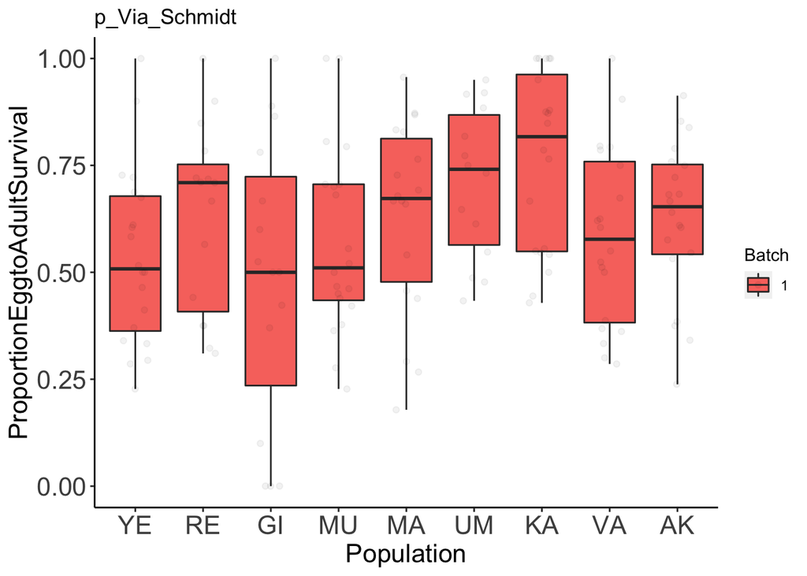

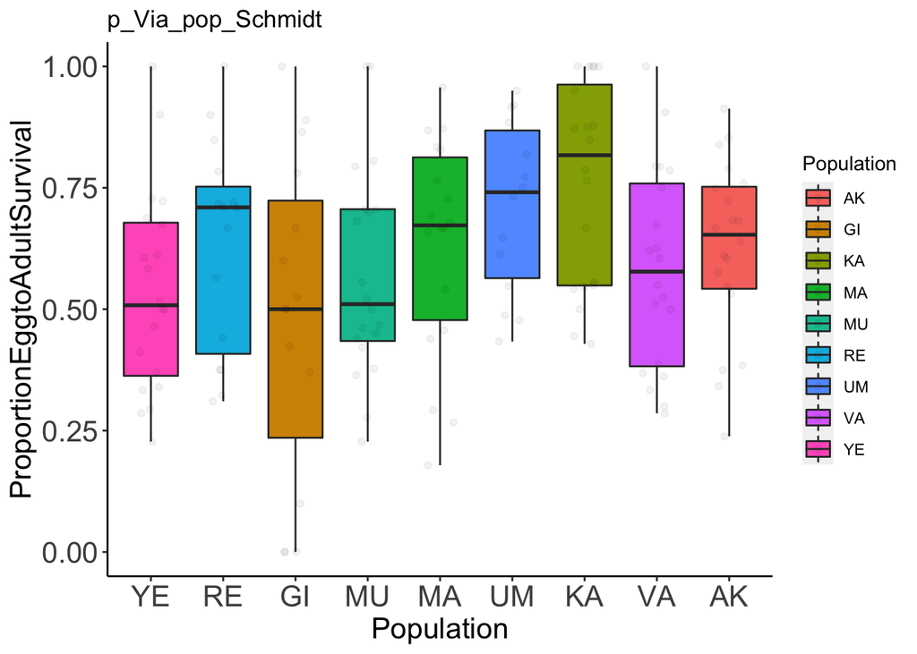

```r
anova(Via_lmer_Schmidt)
```

```
## Analysis of Variance Table
##
## Response: ProportionEggtoAdultSurvival
##             Df Sum Sq  Mean Sq F value  Pr(>F)
## Population   8 1.0046 0.125579  2.5425 0.01256 *
## Residuals  153 7.5570 0.049392
## ---
## Signif. codes:  0 '***' 0.001 '**' 0.01 '*' 0.05 '.' 0.1 ' ' 1
```

```r
summary(Via_lmer_Schmidt)
```

```
##
## Call:
## lm(formula = ProportionEggtoAdultSurvival ~ Population, data = d_Via[d_Via$Supervisor.PI ==
##     "Schmidt", ])
##
## Residuals:
##      Min       1Q   Median       3Q      Max
## -0.48129 -0.19237  0.02616  0.16173  0.51871
##
## Coefficients:
##               Estimate Std. Error t value Pr(>|t|)
## (Intercept)   0.625157   0.049695  12.580   <2e-16 ***
## PopulationGI -0.143866   0.075911  -1.895   0.0600 .
## PopulationKA  0.135186   0.070280   1.924   0.0563 .
## PopulationMA  0.007477   0.072206   0.104   0.9177
## PopulationMU -0.052544   0.070280  -0.748   0.4558
## PopulationRE  0.004666   0.075911   0.061   0.9511
## PopulationUM  0.085505   0.077444   1.104   0.2713
## PopulationVA -0.041436   0.070280  -0.590   0.5563
## PopulationYE -0.087422   0.070280  -1.244   0.2154
## ---
## Signif. codes:  0 '***' 0.001 '**' 0.01 '*' 0.05 '.' 0.1 ' ' 1
##
## Residual standard error: 0.2222 on 153 degrees of freedom
## Multiple R-squared:  0.1173, Adjusted R-squared:  0.07119
## F-statistic: 2.542 on 8 and 153 DF,  p-value: 0.01256
```

#### Stamenkovic-Radak Lab

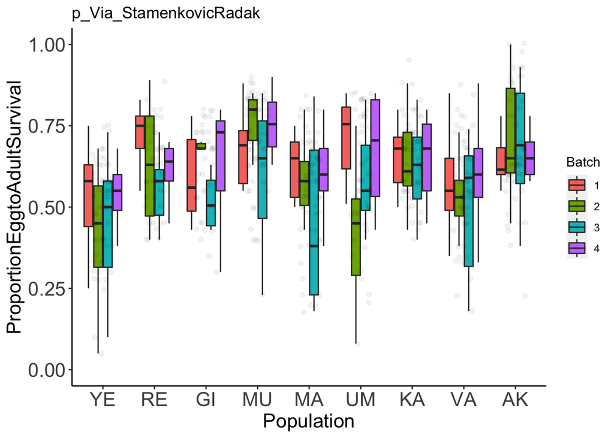

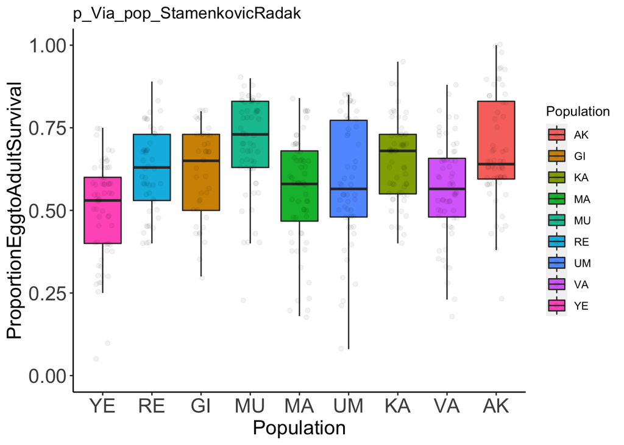

```r
anova(Via_lmer_StamenkovicRadak)
```

```
## Type III Analysis of Variance Table with Satterthwaite's method
##             Sum Sq  Mean Sq NumDF  DenDF F value    Pr(>F)
## Population 0.39276 0.049095     8 155.26  5.0862 1.243e-05 ***
## ---
## Signif. codes:  0 '***' 0.001 '**' 0.01 '*' 0.05 '.' 0.1 ' ' 1
```

```r
summary(Via_lmer_StamenkovicRadak)
```

```
## Linear mixed model fit by REML. t-tests use Satterthwaite's method [
## lmerModLmerTest]
## Formula: ProportionEggtoAdultSurvival ~ Population + (1 | Line:Population) +
##     (1 | Batch)
##    Data: d_Via[d_Via$Supervisor.PI == "StamenkovicRadak", ]
##
## REML criterion at convergence: -589.4
##
## Scaled residuals:
##     Min      1Q  Median      3Q     Max
## -3.6754 -0.5185  0.0052  0.5759  2.2517
##
## Random effects:
##  Groups          Name        Variance Std.Dev.
##  Line:Population (Intercept) 0.013176 0.11479
##  Batch           (Intercept) 0.001207 0.03475
##  Residual                    0.009652 0.09825
## Number of obs: 501, groups:  Line:Population, 167; Batch, 4
##
## Fixed effects:
##               Estimate Std. Error        df t value Pr(>|t|)
## (Intercept)    0.67693    0.03355  21.98005  20.176 1.13e-15 ***
## PopulationGI  -0.07436    0.04570 155.38082  -1.627  0.10573
## PopulationKA  -0.02793    0.04054 155.23842  -0.689  0.49191
## PopulationMA  -0.12034    0.04051 155.10198  -2.971  0.00344 **
## PopulationMU   0.02403    0.04051 155.08224   0.593  0.55386
## PopulationRE  -0.05090    0.04302 155.34042  -1.183  0.23859
## PopulationUM  -0.08775    0.04168 155.34524  -2.106  0.03685 *
## PopulationVA  -0.11615    0.04051 155.10172  -2.867  0.00472 **
## PopulationYE  -0.18226    0.04054 155.23842  -4.496 1.35e-05 ***
## ---
## Signif. codes:  0 '***' 0.001 '**' 0.01 '*' 0.05 '.' 0.1 ' ' 1
##
## Correlation of Fixed Effects:
##             (Intr) PpltGI PpltKA PpltMA PpltMU PpltRE PpltUM PpltVA
## PopulatinGI -0.535
## PopulatinKA -0.606  0.443
## PopulatinMA -0.603  0.441  0.499
## PopulatinMU -0.605  0.442  0.500  0.500
## PopulatinRE -0.571  0.415  0.472  0.471  0.472
## PopulatinUM -0.590  0.429  0.488  0.486  0.487  0.460
## PopulatinVA -0.604  0.445  0.500  0.499  0.500  0.470  0.485
## PopulatinYE -0.606  0.443  0.501  0.499  0.500  0.472  0.488  0.500
```

#### Zwaan Lab

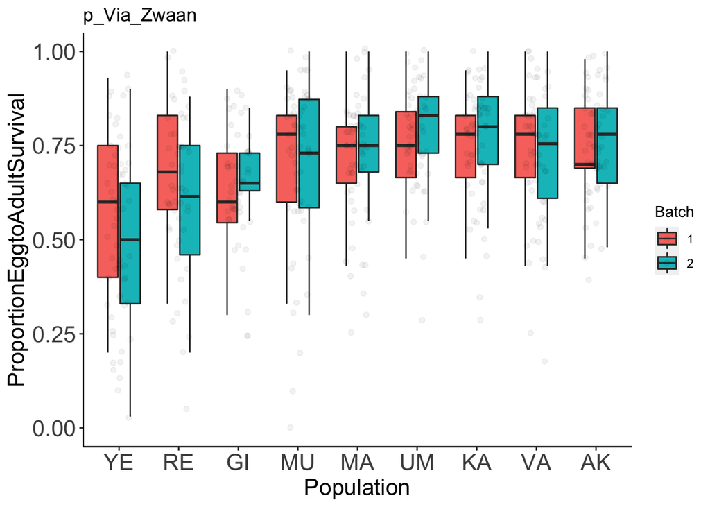

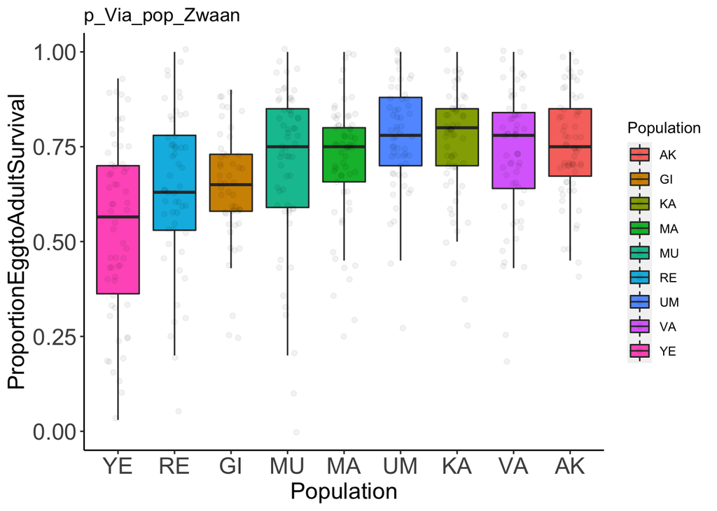

```r
anova(Via_lmer_Zwaan)
```

```
## Type III Analysis of Variance Table with Satterthwaite's method
##            Sum Sq Mean Sq NumDF  DenDF F value    Pr(>F)
## Population 1.1594 0.14492     8 151.78  6.6463 1.944e-07 ***
## ---
## Signif. codes:  0 '***' 0.001 '**' 0.01 '*' 0.05 '.' 0.1 ' ' 1
```

```r
summary(Via_lmer_Zwaan)
```

```
## Linear mixed model fit by REML. t-tests use Satterthwaite's method [
## lmerModLmerTest]
## Formula: ProportionEggtoAdultSurvival ~ Population + (1 | Line:Population) +
##     (1 | Batch)
##    Data: d_Via[d_Via$Supervisor.PI == "Zwaan", ]
##
## REML criterion at convergence: -328.3
##
## Scaled residuals:
##     Min      1Q  Median      3Q     Max
## -3.8665 -0.4405  0.1045  0.5674  2.7223
##
## Random effects:
##  Groups          Name        Variance Std.Dev.
##  Line:Population (Intercept) 0.01052  0.1025
##  Batch           (Intercept) 0.00000  0.0000
##  Residual                    0.02180  0.1477
## Number of obs: 524, groups:  Line:Population, 169; Batch, 2
##
## Fixed effects:
##                Estimate Std. Error         df t value Pr(>|t|)
## (Intercept)    0.753292   0.029612 148.129254  25.439  < 2e-16 ***
## PopulationGI  -0.109677   0.045264 147.538931  -2.423   0.0166 *
## PopulationKA   0.006964   0.042022 149.533027   0.166   0.8686
## PopulationMA  -0.039616   0.042055 150.208886  -0.942   0.3477
## PopulationMU  -0.045938   0.042393 153.358912  -1.084   0.2802
## PopulationRE  -0.107348   0.044247 145.966515  -2.426   0.0165 *
## PopulationUM   0.025615   0.043113 148.966551   0.594   0.5533
## PopulationVA  -0.020760   0.042344 153.060112  -0.490   0.6247
## PopulationYE  -0.226033   0.042298 153.374414  -5.344 3.24e-07 ***
## ---
## Signif. codes:  0 '***' 0.001 '**' 0.01 '*' 0.05 '.' 0.1 ' ' 1
##
## Correlation of Fixed Effects:
##             (Intr) PpltGI PpltKA PpltMA PpltMU PpltRE PpltUM PpltVA
## PopulatinGI -0.654
## PopulatinKA -0.705  0.461
## PopulatinMA -0.704  0.461  0.496
## PopulatinMU -0.698  0.457  0.492  0.492
## PopulatinRE -0.669  0.438  0.472  0.471  0.467
## PopulatinUM -0.687  0.449  0.484  0.484  0.480  0.460
## PopulatinVA -0.699  0.457  0.493  0.492  0.488  0.468  0.480
## PopulatinYE -0.700  0.458  0.493  0.493  0.489  0.469  0.481  0.490
## optimizer (nloptwrap) convergence code: 0 (OK)
## boundary (singular) fit: see ?isSingular
```

#### **Hoedjes Lab**

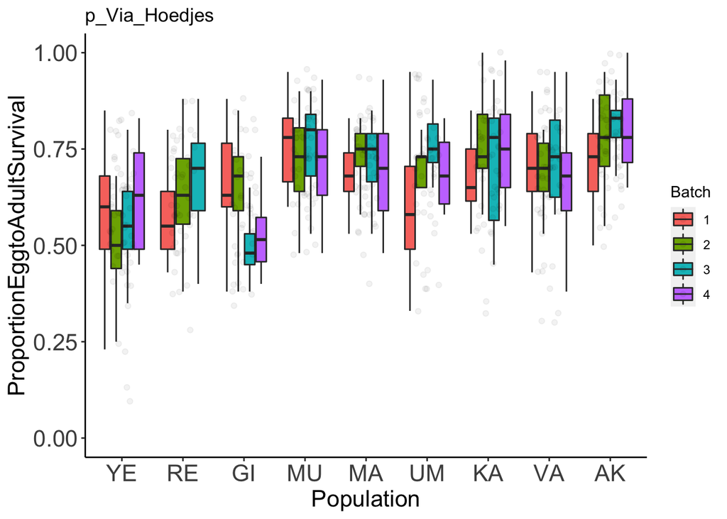

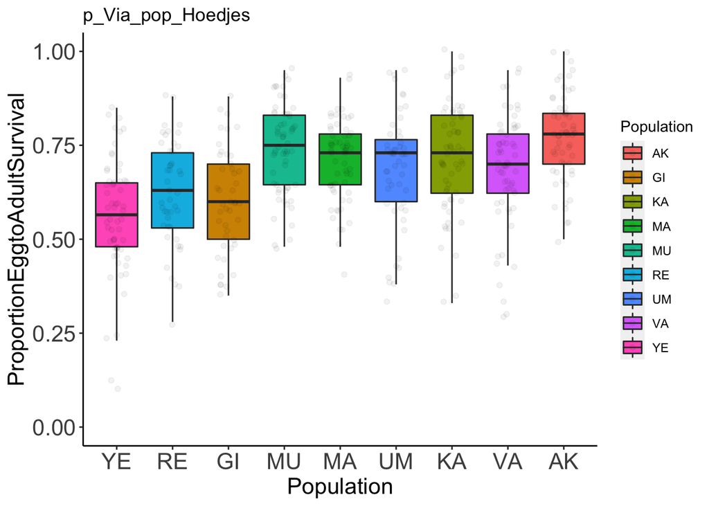

```r
anova(Via_lmer_Hoedjes)
```

```
## Type III Analysis of Variance Table with Satterthwaite's method
##             Sum Sq  Mean Sq NumDF DenDF F value    Pr(>F)
## Population 0.35451 0.044314     8   158  6.1992 5.871e-07 ***
## ---
## Signif. codes:  0 '***' 0.001 '**' 0.01 '*' 0.05 '.' 0.1 ' ' 1
```

```r
summary(Via_lmer_Hoedjes)
```

```
## Linear mixed model fit by REML. t-tests use Satterthwaite's method [
## lmerModLmerTest]
## Formula: ProportionEggtoAdultSurvival ~ Population + (1 | Line:Population) +
##     (1 | Batch)
##    Data: d_Via[d_Via$Supervisor.PI == "Hoedjes", ]
##
## REML criterion at convergence: -712.5
##
## Scaled residuals:
##     Min      1Q  Median      3Q     Max
## -3.7848 -0.5126 -0.0026  0.5498  2.7446
##
## Random effects:
##  Groups          Name        Variance  Std.Dev.
##  Line:Population (Intercept) 1.219e-02 1.104e-01
##  Batch           (Intercept) 2.196e-12 1.482e-06
##  Residual                    7.148e-03 8.455e-02
## Number of obs: 501, groups:  Line:Population, 167; Batch, 4
##
## Fixed effects:
##               Estimate Std. Error        df t value Pr(>|t|)
## (Intercept)    0.77450    0.02699 157.99983  28.694  < 2e-16 ***
## PopulationGI  -0.17183    0.04123 157.99984  -4.168 5.06e-05 ***
## PopulationKA  -0.05633    0.03817 157.99984  -1.476 0.141995
## PopulationMA  -0.06600    0.03817 157.99984  -1.729 0.085761 .
## PopulationMU  -0.03500    0.03817 157.99984  -0.917 0.360593
## PopulationRE  -0.15117    0.04123 157.99985  -3.666 0.000336 ***
## PopulationUM  -0.08960    0.03982 157.99985  -2.250 0.025827 *
## PopulationVA  -0.09367    0.03817 157.99984  -2.454 0.015222 *
## PopulationYE  -0.21483    0.03817 157.99984  -5.628 8.11e-08 ***
## ---
## Signif. codes:  0 '***' 0.001 '**' 0.01 '*' 0.05 '.' 0.1 ' ' 1
##
## Correlation of Fixed Effects:
##             (Intr) PpltGI PpltKA PpltMA PpltMU PpltRE PpltUM PpltVA
## PopulatinGI -0.655
## PopulatinKA -0.707  0.463
## PopulatinMA -0.707  0.463  0.500
## PopulatinMU -0.707  0.463  0.500  0.500
## PopulatinRE -0.655  0.429  0.463  0.463  0.463
## PopulatinUM -0.678  0.444  0.479  0.479  0.479  0.444
## PopulatinVA -0.707  0.463  0.500  0.500  0.500  0.463  0.479
## PopulatinYE -0.707  0.463  0.500  0.500  0.500  0.463  0.479  0.500
## optimizer (nloptwrap) convergence code: 0 (OK)
## boundary (singular) fit: see ?isSingular
```

#### Grath Lab

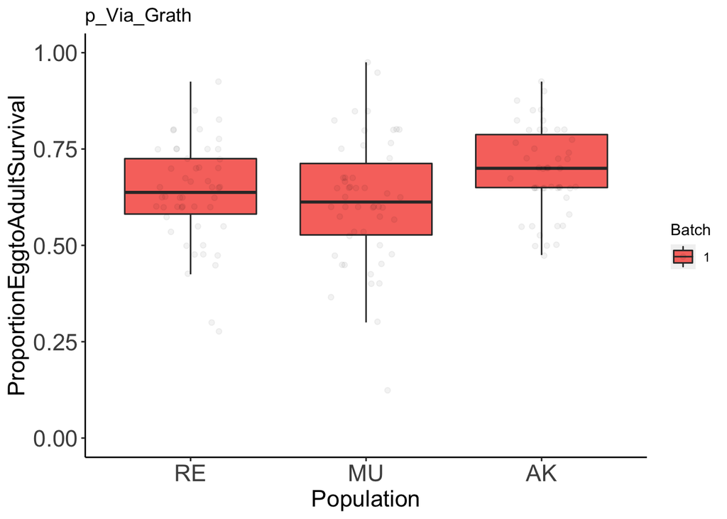

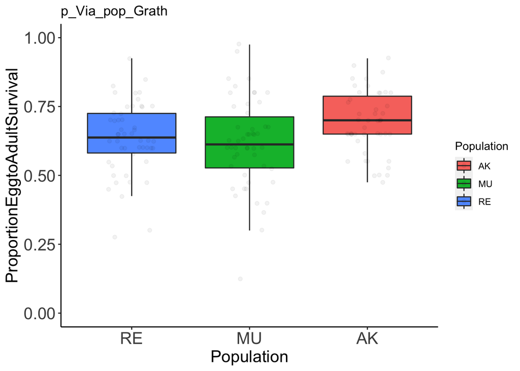

```r
anova(Via_lmer_Grath)
```

```
## Type III Analysis of Variance Table with Satterthwaite's method
##             Sum Sq  Mean Sq NumDF  DenDF F value Pr(>F)
## Population 0.07035 0.035175     2 27.293  2.1926 0.1309
```

```r
summary(Via_lmer_Grath)
```

```
## Linear mixed model fit by REML. t-tests use Satterthwaite's method [
## lmerModLmerTest]
## Formula: ProportionEggtoAdultSurvival ~ Population + (1 | Line:Population)
##    Data: d_Via[d_Via$Supervisor.PI == "Grath", ]
##
## REML criterion at convergence: -155.6
##
## Scaled residuals:
##      Min       1Q   Median       3Q      Max
## -3.14211 -0.56745  0.04161  0.55412  2.60033
##
## Random effects:
##  Groups          Name        Variance Std.Dev.
##  Line:Population (Intercept) 0.003394 0.05826
##  Residual                    0.016043 0.12666
## Number of obs: 147, groups:  Line:Population, 30
##
## Fixed effects:
##              Estimate Std. Error       df t value Pr(>|t|)
## (Intercept)   0.69027    0.02612 28.41694  26.424   <2e-16 ***
## PopulationMU -0.07424    0.03664 27.57805  -2.026   0.0525 .
## PopulationRE -0.05444    0.03664 27.57805  -1.486   0.1487
## ---
## Signif. codes:  0 '***' 0.001 '**' 0.01 '*' 0.05 '.' 0.1 ' ' 1
##
## Correlation of Fixed Effects:
##             (Intr) PpltMU
## PopulatinMU -0.713
## PopulatinRE -0.713  0.508
```

#### Gibert Lab

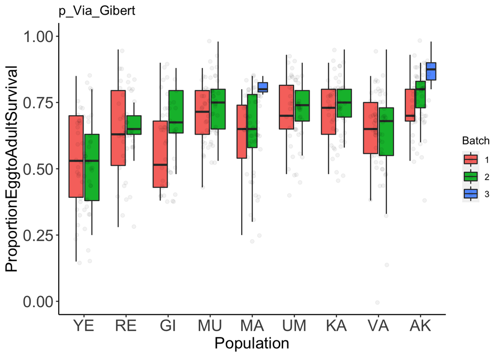

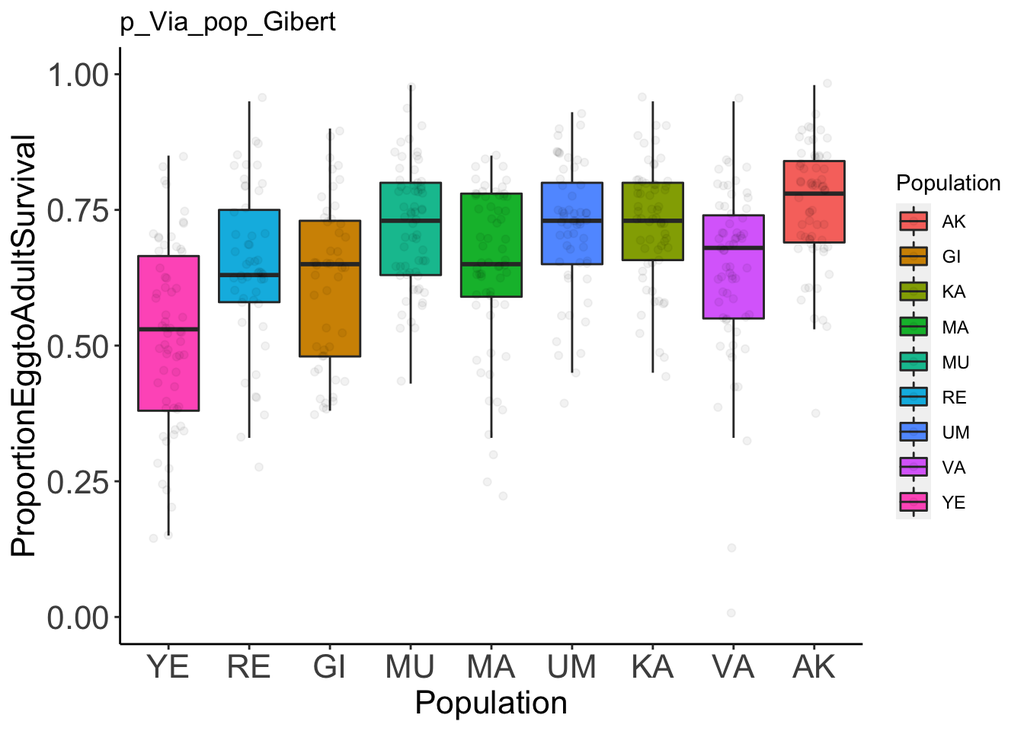

```r
anova(Via_lmer_Gibert)
```

```
## Type III Analysis of Variance Table with Satterthwaite's method
##            Sum Sq  Mean Sq NumDF  DenDF F value    Pr(>F)
## Population 0.6029 0.075362     8 154.72  8.1983 3.224e-09 ***
## ---
## Signif. codes:  0 '***' 0.001 '**' 0.01 '*' 0.05 '.' 0.1 ' ' 1
```

```r
summary(Via_lmer_Gibert)
```

```
## Linear mixed model fit by REML. t-tests use Satterthwaite's method [
## lmerModLmerTest]
## Formula: ProportionEggtoAdultSurvival ~ Population + (1 | Line:Population) +
##     (1 | Batch)
##    Data: d_Via[d_Via$Supervisor.PI == "Gibert", ]
##
## REML criterion at convergence: -687.4
##
## Scaled residuals:
##     Min      1Q  Median      3Q     Max
## -4.8895 -0.5220  0.0038  0.5549  2.4861
##
## Random effects:
##  Groups          Name        Variance  Std.Dev.
##  Line:Population (Intercept) 1.064e-02 0.103146
##  Batch           (Intercept) 6.195e-05 0.007871
##  Residual                    9.192e-03 0.095877
## Number of obs: 532, groups:  Line:Population, 169; Batch, 3
##
## Fixed effects:
##               Estimate Std. Error        df t value Pr(>|t|)
## (Intercept)    0.75693    0.02658  51.26227  28.476  < 2e-16 ***
## PopulationGI  -0.14773    0.03986 155.28178  -3.706 0.000292 ***
## PopulationKA  -0.03422    0.03696 155.95970  -0.926 0.355981
## PopulationMA  -0.11278    0.03691 154.48413  -3.056 0.002647 **
## PopulationMU  -0.03629    0.03692 155.28351  -0.983 0.327104
## PopulationRE  -0.11002    0.03921 155.98273  -2.806 0.005655 **
## PopulationUM  -0.04241    0.03792 155.09608  -1.118 0.265136
## PopulationVA  -0.12079    0.03692 155.28351  -3.272 0.001316 **
## PopulationYE  -0.24601    0.03692 155.28351  -6.664 4.38e-10 ***
## ---
## Signif. codes:  0 '***' 0.001 '**' 0.01 '*' 0.05 '.' 0.1 ' ' 1
##
## Correlation of Fixed Effects:
##             (Intr) PpltGI PpltKA PpltMA PpltMU PpltRE PpltUM PpltVA
## PopulatinGI -0.640
## PopulatinKA -0.691  0.462
## PopulatinMA -0.693  0.463  0.500
## PopulatinMU -0.692  0.463  0.500  0.500
## PopulatinRE -0.651  0.437  0.470  0.470  0.471
## PopulatinUM -0.673  0.451  0.487  0.487  0.487  0.458
## PopulatinVA -0.692  0.463  0.500  0.500  0.500  0.471  0.487
## PopulatinYE -0.692  0.463  0.500  0.500  0.500  0.471  0.487  0.500
```

### Lab correlations

## Developmental time

### Egg-to-pupa developmental time

#### Data Reformatting

#### Descriptive Statistics

#### Plots and Linear Models by Lab

##### Schmidt Lab

### Egg-to-adult developmental time

#### Data Reformatting

#### Descriptive Statistics

#### Plots and Linear Models by Lab

##### Gibert Lab

##### Grath Lab

##### Hoedjes Lab

##### Schmidt Lab

##### Stamenkovic-Radak Lab

##### Zwaan Lab

#### Lab correlations

## Dry weight

### Data Reformatting

### Descriptive Statistics

### Plots and Linear Models by Lab

#### Colinet Lab

#### Hoedjes Lab

#### Onder Lab

### Lab correlations

## Thorax length

### Data Reformatting

### Descriptive Statistics

### Plots and Linear Models by Lab

#### Kozeretska Lab

#### Posnien Lab

#### Ritchie Lab

#### Schmidt Lab

### Lab correlations

## Wing area - Right

### Data Reformatting

### Descriptive Statistics

### Plots and Linear Models by Lab

#### Onder Lab

#### Posnien Lab

#### Ritchie Lab

#### Stamenkovic-Radak Lab

### Lab correlations

## Wing area - Left

### Data Reformatting

### Descriptive Statistics

### Plots and Linear Models by Lab

#### Onder Lab

#### Posnien Lab

#### Ritchie Lab

#### Stamenkovic-Radak Lab

### Lab correlations

## Fecundity

### Data Reformatting

### Descriptive Statistics

### Plots and Linear Models by Lab

#### Billeter Lab

#### Fricke Lab

### Lab correlations

## Lifespan

### Data Reformatting

### Descriptive Statistics

### Plots and Linear Models by Lab

#### Flatt Lab

#### Parsch Lab

#### Pasyukova Lab

### Survival Analyses

#### Flatt Lab

#### Parsch Lab

#### Pasyukova Lab

### Lab correlations

## Cold-shock mortality

### Data Reformatting

### Descriptive Statistics

### Plots and Linear Models by Lab

#### Gonzalez Lab

#### Kozeretska Lab

#### Vieira Lab

### Lab correlations

## Chill-coma recovery time

### Data Reformatting

### Descriptive Statistics

### Plots and Linear Models by Lab

#### Vieira Lab

#### Mensh Lab

### Lab correlations

## Heat-shock mortality

### Data Reformatting

### Descriptive Statistics

### Plots and Linear Models by Lab

#### Parsch Lab

#### Vieira Lab

### Lab correlations

## Diapause

### Data Reformatting

### Descriptive Statistics

### Plots and Linear Models by Lab

#### Bergland Lab

#### Flatt Lab

#### Schlotterer Lab

### Lab correlations

## Circadian eclosion timing

### Data Reformatting

### Descriptive Statistics

### Plots and Linear Models by Lab

#### Wegener Lab

## Locomotor activity

### Data Reformatting

### Descriptive Statistics

### Plots and Linear Models by Lab

#### Tauber Lab

## Starvation resistance

### Data Reformatting

### Descriptive Statistics

### Plots and Linear Models by Lab

#### Gonzalez Lab

#### Onder Lab

#### Pasyukova Lab

### Survival Analyses

#### Gonzalez Lab

#### Onder Lab

#### Pasyukova Lab

### Lab correlations

## Pigmentation

### Data Reformatting

### Descriptive Statistics

### Plots and Linear Models by Lab

#### Abbott Lab

#### Gibert Lab

#### Schmidt Lab

### Lab correlations

# Results II : Meta-Analyses

## with Diet

## with Wolbachia

# Results III : Trait Correlations

## Stress related traits

## Temperature related traits

## Size related traits

# Results III : Qst - Fst

# Results IV : Environmental Variables

# Results V : Heritability